# FigureYa201ClusterCorrelation

**Author(s)**: Xiaofan Lu  
**Reviewers**: Ying Ge,Hui Huang  
**Date**: 2025-11-30

## 1 Academic Citation

If you use this code in your work or research, we kindly request that you cite our publication:

Xiaofan Lu, et al. (2025). FigureYa: A Standardized Visualization Framework for Enhancing Biomedical Data Interpretation and Research Efficiency. iMetaMed. https://doi.org/10.1002/imm3.70005

## 2 需求描述 Requirement Description

根据基因表达进行非监督聚类，之后划分为正负相关基因集。

Unsupervised clustering was performed based on gene expression, after which it was divided into positive and negatively correlated gene sets.

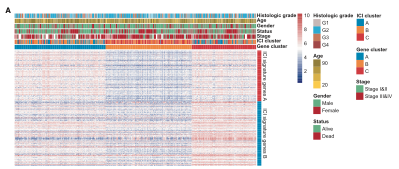

From https://www.cell.com/molecular-therapy-family/nucleic-acids/fulltext/S2162-2531(20)30259-6

Figure 2. Identification of Immunogenic Gene Subtypes A) Unsupervised clustering of common DEGs among three ICI cluster groups to classify patients into three groups: gene clusters A–C.

## 3 应用场景 Application Scenarios

根据基因表达进行非监督共识聚类，划分正负相关基因集。

Unsupervised consensus clustering was performed based on gene expression, and positive and negative correlation gene sets were divided.

FigureYa154immuneSubtypes和FigureYa202consensusGene也用到了ConsensusClusterPlus做共识聚类，可相互参考，灵活运用，设计出更有趣的展示方式。

FigureYa154immuneSubtypes and FigureYa202consensusGene also use ConsensusClusterPlus for consensus clustering, which can be used for mutual reference and flexible use to design more interesting display methods.

问：“什么叫非监督共识聚类？”

ConsensusClusterPlus包的描述：ConsensusClusterPlus function for determing cluster number and class membership by stability evidence.

Xiaofan Lu作出以下解答：

- **共识聚类**是对原数据集重新抽样，对抽样子集做聚类。
  - **多次重复**来评估样本同属于相同类的概率，这种是常用的consensus clustering。
  - 用**不同算法**聚类来综合结果是另一种共识，这个一般叫consensus ensemble。后者属于later integration后期整合的一种。
- **非监督**就是在你并不知道有多少类的情况下，没有目的的进行聚类，然后根据一些统计量确定最优结果。
- 当你有了一些先验知识，有目的的进行聚类分析，一般是在某个感兴趣的数据集上直接明确聚类数目就是**监督聚类**了。

What is Unsupervised Consensus Clustering?

Here’s my explanation:

- **Consensus Clustering** involves resampling the original dataset and performing clustering on subsets.
  - **Repeated iterations** assess the probability that samples consistently belong to the same class—this is the classic consensus clustering approach.
  - **Combining results from different clustering algorithms** is another form of consensus, typically called consensus ensemble clustering. The latter falls under late integration in multi-method workflows.
- **Unsupervised** means clustering without prior knowledge of the number of classes, then determining the optimal result based on statistical metrics (e.g., consensus scores, silhouette width).
- When prior knowledge guides the analysis (e.g., a predefined cluster number in a target dataset), it becomes **supervised clustering**.

## 4 环境设置 Environment settings

```r
source("install_dependencies.R")
```

```
## Starting R package installation...
## ===========================================
##
## Installing CRAN packages...
## Package already installed: pheatmap
##
## Installing Bioconductor packages...
## Package already installed: ConsensusClusterPlus
##
## ===========================================
## Package installation completed!
## You can now run your R scripts in this directory.
```

```r
library(ConsensusClusterPlus) # 加载共识聚类包 # Load consensus clustering package
library(pheatmap) # 画热图 # heatmap package

Sys.setenv(LANGUAGE = "en") #显示英文报错信息 # Display English error messages
options(stringsAsFactors = FALSE) #禁止chr转成factor # Prohibit converting chr to factor
```

## 5 输入文件 Input Files

easy_input_expr.txt，包含目标基因的表达矩阵，将从这里提取目标基因的表达矩阵。

easy_input_gene.txt, 目标基因，用来聚类和画图，来自原文Table S2的三个亚型的差异表达基因，取并集。

easy_input_expr.txt, Contains the expression matrix of target genes.This file will be used to extract the expression profiles of the specified genes.

easy_input_gene.txt, Lists target genes for clustering and plotting.Derived from the union of differentially expressed genes (DEGs) across three subtypes in Table S2 of the original publication.

```r
# 加载基因表达谱 # Load gene expression matrix
expr <- read.table("easy_input_expr.txt",sep = "\t",row.names = 1,check.names = F,stringsAsFactors = F,header = T)
dim(expr)
```

```
## [1] 1069  544
```

```r
expr[1:3, 1:3]
```

```
##       HNSC-6998-01 HNSC-A4II-01 HNSC-7423-01
## FGR           0.98         1.96         0.33
## CFH           5.55         2.82         1.96
## ENPP4         0.10         0.38         0.04
```

```r
# 加载样本信息 # Load sample information
clin <- read.table("easy_input_sinfo.txt",sep = "\t",row.names = 1,check.names = F,stringsAsFactors = F,header = T)
clin[1:3,]
```

```
##              Gender Status Grade Age
## HNSC-AA8J-01   Male  Alive    G2  66
## HNSC-4074-01   Male   Dead    G3  69
## HNSC-4075-01   Male   Dead    G2  49
```

```r
# 加载用于聚类的目标基因 # Load the target gene for clustering
degs <- read.table("easy_input_gene.txt",sep = "\t", row.names = NULL, header = F,stringsAsFactors = F,check.names = F)
head(degs)
```

```
##       V1
## 1  CXCL8
## 2  CXCL5
## 3   IL1B
## 4 MCEMP1
## 5   AQP9
## 6   CSF2
```

```r
# 提取用于聚类的基因的表达矩阵 # Extract the expression matrix of genes used for clustering
comgene <- intersect(rownames(expr), degs$V1) #提取有表达数据的目标基因
comsam <- intersect(colnames(expr), rownames(clin)) #提取既有表达矩阵又有样本信息的样本
indata <- log2(expr[comgene,comsam] + 1) #这里示例数据是FPKM值，+1再取log2，实际应用时根据自己的数据灵活处理
# The example data here uses FPKM values, transformed by adding 1 and then taking log2. In practice, adjust the preprocessing steps flexibly based on your own data characteristics.
indata[1:3,1:3]
```

```
##       HNSC-6998-01 HNSC-A4II-01 HNSC-7423-01
## FGR      0.9855004    1.5655972   0.41142625
## CFH      2.7114949    1.9335726   1.56559718
## ENPP4    0.1375035    0.4646683   0.05658353
```

```r
dim(indata)
```

```
## [1] 1069  480
```

## 6 共识聚类 ConsensusCluster

用ConsensusClusterPlus决定聚类数量。 Use ConsensusClusterPlus to determine the number of clusters.

```r
subtype <- ConsensusClusterPlus(d = as.matrix(indata),
                                maxK = 4, # 原文参数 # Original text parameters
                                pItem = 0.8, # 默认参数 # Default parameters
                                pFeature = 1, # 默认参数 # Default parameters
                                reps = 1000, # 原文参数 # Original text parameters
                                clusterAlg = "pam", # 原文参数 # Original text parameters
                                innerLinkage = "ward.D", # 原文参数 # Original text parameters
                                finalLinkage = "ward.D", # 原文参数 # Original text parameters
                                distance = "euclidean", # 原文参数 # Original text parameters
                                seed = 123456,
                                plot = "pdf", #或png # or png
                                writeTable = TRUE,
                                title = "ConsensusCluster")
```

```
## end fraction
```

```
## clustered
## clustered
## clustered
```

```r
# 打开ConsensusCluster文件夹里的consensus.pdf文件，查看不同分类数量下的聚类结果
# 这里取k=3时的聚类结果
# Open the consensus.pdf file in the ConsensusCluster folder to view the clustering results for different number of categories
# Here we take the clustering result when k=3
geneclust <- subtype[[3]]
table(geneclust$consensusClass)
```

```
##
##   1   2   3
## 175 227  78
```

```r
samorder <- sort(geneclust$consensusClass)
```

题外话：

- 你可能想要每个sample对应的cluster，用来进一步做生存分析、差异表达分析等。打开ConsensusCluster文件夹，ConsensusCluster.k=X.consensusClass.csv对应每种分类数量下sample所在的cluster。
- ConsensusCluster.k=X.consensusMatrix.csv对应consensus.pdf文件里的热图，可以用这个matrix重新DIY更好看的热图。

Aside:

- You may want the cluster corresponding to each sample for further survival analysis, differential expression analysis, etc.Open the ConsensusCluster folder, ConsensusCluster.k=X.consensusClass.csv corresponds to the cluster where the sample is located for each classification number.
- ConsensusCluster.k=X.consensusMatrix.csv corresponds to the heatmap in the consensus.pdf file, and you can use this matrix to DIY a better-looking heatmap.

## 7 计算基因与cluster的相关性 Calculating Gene-Cluster Correlations

该部分我是与作者沟通的，作者回复如下：

gene cluster a b c 分别对应1 2 3，由此计算皮尔森系数。同时随机森林降维也是根据 1 2 3 来进行的。也就是说计算皮尔森系数与降维的依据是一致的。同时 gene cluster 1 2 3是由一致性聚类自动分成的。为了方便表述，文中将其命名为gene cluster a b c。

This section is based on direct communication with the study authors. Their response is summarized below:

1.Gene Clusters (a/b/c) correspond to numerical labels (1/2/3) for analysis purposes.

2.Pearson correlation is calculated between gene expression and these cluster assignments (1/2/3).

3.Random forest-based feature reduction also uses the same numerical labels (1/2/3) for consistency.

4.Cluster derivation: The three gene clusters (1/2/3) were automatically generated by consensus clustering. For clarity in the manuscript, they were renamed as a/b/c in the text.

```r
outTab <- NULL
for (i in rownames(indata)) {
  tmp <- as.numeric(indata[i,names(samorder)])
  cor.res <- cor.test(tmp, as.numeric(samorder), method = "pearson")
  outTab <- rbind.data.frame(outTab,
                             data.frame(gene = i,
                                        r = cor.res$estimate,
                                        p = cor.res$p.value,
                                        stringsAsFactors = F),
                             stringsAsFactors = F)
}

# 按相关性正负来分类
# Categorized by positive and negative correlations
outTab$direct <- ifelse(outTab$r > 0, "A","B") # 正相关标为A，否则标为B # The positive correlation is marked as A, otherwise it is marked as B
outTab <- outTab[order(outTab$r, decreasing = T),]
table(outTab$direct) # 事实上最终用于展示热图的基因数目更少，因为作者进一步采用了随机森林降维 # In fact, the number of genes used to display the heatmap was even smaller because the authors further employed random forest dimensionality reduction
```

```
##
##   A   B
## 938 131
```

```r
# 把基因与cluster的相关系数r、p值及其所属的基因集（A、B）保存到文件
# # Save the correlation coefficients r, p, and gene sets (A, B) of genes to a file
write.table(outTab,"ouput_ICIsignatureGene.txt",sep = "\t", row.names = F, col.names = T, quote = F)
```

## 8 开始画图 Drawing

用pheamap画图，把样本信息写到annotation里，在图中标注出来。

Draw a map with pheamap, write the sample information into the annotation, and mark it in the image.

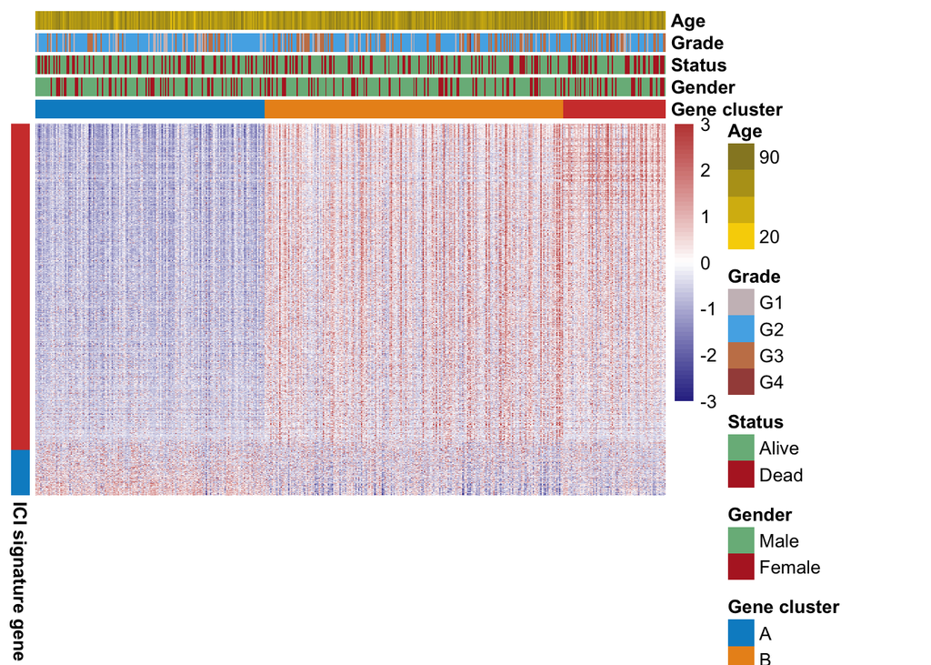

```r
annCol <- data.frame("Gene cluster" = ifelse(samorder == 1,"A", ifelse(samorder == 2, "B", "C")),
                     row.names = names(samorder),
                     check.names = F,
                     stringsAsFactors = F)
annCol <- cbind.data.frame(annCol,clin[rownames(annCol),])

annRow <- data.frame("ICI signature gene" = outTab$direct,
                     row.names = outTab$gene,
                     check.names = F,
                     stringsAsFactors = F)
annColors <- list("Gene cluster" = c("A" = "#008ECB", "B" = "#EA921D", "C" = "#D14039"),
                  "Gender" = c("Male" = "#79B789", "Female" = "#B5262A"),
                  "Status" = c("Alive" = "#79B789", "Dead" = "#B5262A"),
                  "Grade" = c("G1" = "#CBBEC1", "G2" = "#53B1E7", "G3" = "#C78157", "G4" = "#A54D48"),
                  "Age" = colorRampPalette(c("#F7D202", "#96862A"))(64),
                  "ICI signature gene" = c("A" = "#D14039", "B" = "#008ECB"))

plotdata <- t(scale(t(indata[rownames(annRow), rownames(annCol)])))
plotdata[plotdata > 3] <- 3 # 截断极端值 # Truncate extreme values
plotdata[plotdata < -3] <- -3 # 截断极端值 # Truncate extreme values

pheatmap(plotdata,
         cluster_rows = F,
         cluster_cols = F,
         show_rownames = F,
         show_colnames = F,
         annotation_row = annRow,
         annotation_col = annCol,
         annotation_colors = annColors,
         color = colorRampPalette(c("#343493", "white", "#C24A45"))(64))
```

```r
dev.copy2pdf(file = "ClusterCorrelation.pdf", width = 10, height = 8) # 保存图像 # save image
```